# Analyse multidimensionnelle de la précarité dans le système urbain français

#### 3.3.2.3 Cartographie Local Moran Axe 1

```r
# tableau des local moran pour deux distances
dfaxe1 <- localmoran_results$detailed[["Dim.1_polygon_dist_30000_FALSE"]] %>%
   bind_cols("AU2010" = df2$AU2010, .)

dfaxe1 <- dfaxe1 %>%
  mutate(Dist = "30 km") %>%
  # ajout de la seconde distance 70 km
  bind_rows(localmoran_results$detailed[["Dim.1_polygon_dist_70000_FALSE"]] %>%
   bind_cols("AU2010" = df2$AU2010, .)) %>%
# colonne pour la seconde distance
  mutate(Dist = if_else(is.na(Dist), "70 km", Dist)) %>%
    # création de colonnes pour afficher la typo quadrant quand la pseudo pvalue est < 0.005
  mutate(localmoranAxe1 = case_when(`Pr(z != E(Ii))` < 0.005 ~ `mean`,
         T ~ "NS"),
         localmoranAxe1_adjust = case_when(p.value.fdr < 0.005 ~ `mean`,
         T ~ "NS"))

# ajout de l'information aux géométrie
carto_moran <- AUsf_93 %>% left_join(dfaxe1)



unique(carto_moran$localmoranAxe1_adjust)
```

```
## [1] "NS"        "Low-Low"   "High-High" "Low-High"  "High-Low"
```

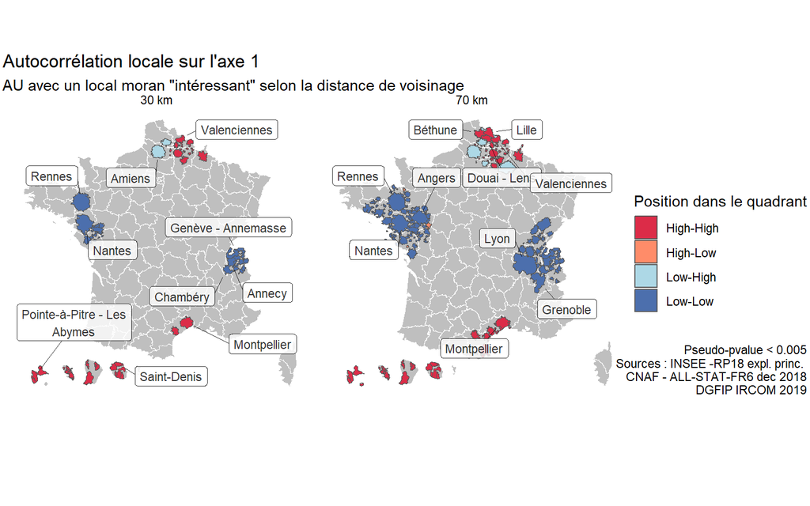

```r
# ajout d'info AU pour la carto
carto_moran <- carto_moran %>%
  left_join(select(au_info, AU2010, LIBAU2010, LIBDEP,LIBREG, pop18_au, TaillAU18 ))
# vecteur de couleur
colCAH <- setNames(c( "#4C6FAD", "grey"  , "#DC2C48", "lightblue", "salmon1" ),
                   c("Low-Low" , "NS","High-High", "Low-High","High-Low" ) )

# tableau des 10 villes les plus peuplées pour les label

top_villes_dist1 <- carto_moran %>%
  filter(Dist == "30 km") %>%
  filter(localmoranAxe1_adjust != "NS") %>%
  top_n(10, pop18_au) %>%
  select(geometry, "LABEL_AU" = LIBAU2010 , pop18_au, Dist)

top_villes_dist2 <- carto_moran %>%
  filter(Dist == "70 km") %>%
  filter(localmoranAxe1_adjust != "NS") %>%
  top_n(10, pop18_au) %>%
  select(geometry, "LABEL_AU" = LIBAU2010 , pop18_au, Dist)


top_villes <- bind_rows(top_villes_dist1, top_villes_dist2) %>%
  # raccourcir label
  mutate(LABEL_AU = str_remove(LABEL_AU, " \\s*\\([^\\)]+\\)")) %>%
  mutate(LABEL_AU = str_remove(LABEL_AU, " \\s*\\([^\\)]+\\)"))

rm(top_villes_dist1, top_villes_dist2)


g <- ggplot() +
  geom_sf(data =depsf, fill = "#bfbfbf", color = "white", size = 0.5) +
  geom_sf(data = carto_moran %>%
            filter(localmoranAxe1_adjust != "NS") ,
          mapping = aes(fill = localmoranAxe1_adjust ), size = 0.25) +
   geom_label_repel(
    data = top_villes,
    aes(label = str_wrap(LABEL_AU, 20),
        geometry = geometry),
    stat = "sf_coordinates",
    size = 3,
    force = 1,
     point.padding = 0.7,
    alpha = 0.8,
     segment.color = "black", # Couleur du segment
    segment.size = 0.3,     # Épaisseur du segment
    segment.alpha = 0.8,    # Transparence du segment
    min.segment.length = 0,
    box.padding = 0.7 ,
    max.overlaps = Inf
  ) +
  scale_fill_manual(values = colCAH) +
  theme_void() +
  facet_wrap(~Dist) +
  labs(title = "Autocorrélation locale sur l'axe 1",
       subtitle = "AU avec un local moran \"intéressant\" selon la distance de voisinage",
       fill = "Position dans le quadrant",
       caption = "Pseudo-pvalue < 0.005\nSources : INSEE -RP18 expl. princ. \n CNAF - ALL-STAT-FR6 dec 2018\n DGFIP IRCOM 2019") +
    theme(plot.caption.position = "plot",
        plot.caption =element_text(vjust=25),
        plot.margin = unit(c(0, 2, 0, 2), "points"))
g
```

```r
# enlever titre et sous-titre
g <- g + labs(title = "", subtitle = "")


# ggsave(plot = g,
#        path =  "../Output/",
#        filename = "carto_lm_axe1_30km_70km.png",
#        width = 210,
#        height = 148,
#        dpi = 300,
#        units = "mm")
```

## 3.4 CAH

Réalisation d’une classification ascendante hiérarchique (CAH) avec critère de Ward.

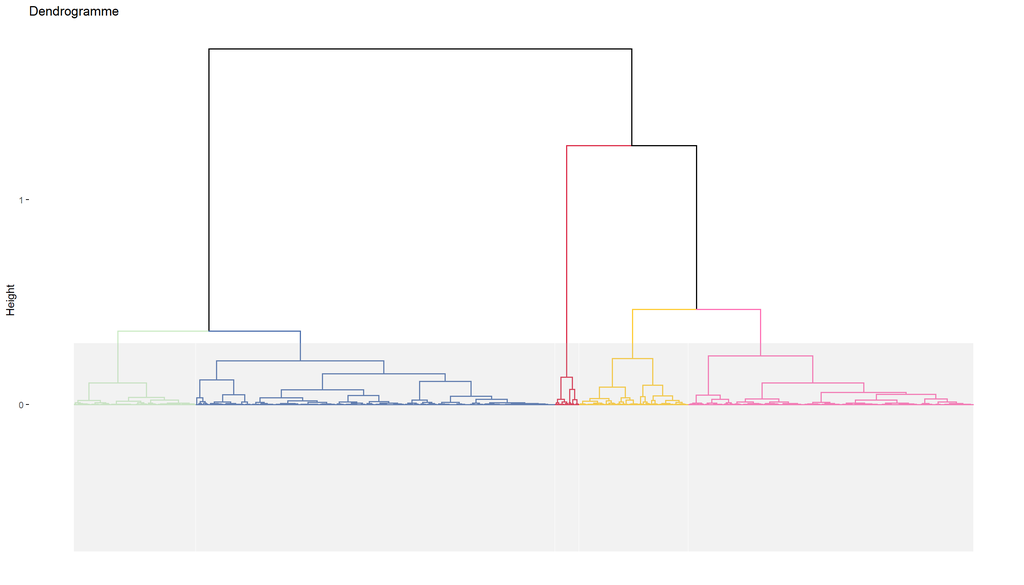

```r
## CAH nb classes

res.hcpc <- HCPC(res.pca,
                 graph = FALSE,
                 method = "ward" ,
                 min = 5,
                 max = 8,
                 nb.par = 10,
                 description = TRUE,
                 proba = 1) # IMPORTANT pour garder les Axes et variables non significatifs)


# couleur des classes

colCAH <- setNames(c("#CCEBC5", "#4C6FAD",   "#DC2C48", "#FFCC33",  "hotpink1" ),
                   c(1,2,3,4,5) )


fviz_dend(res.hcpc,
          show_labels = FALSE,
          palette = colCAH,               # Color palette ggpubr
          rect = TRUE,
          rect_fill = TRUE, # Add rectangle around groups
          main = "Dendrogramme")           # Rectangle color )
```

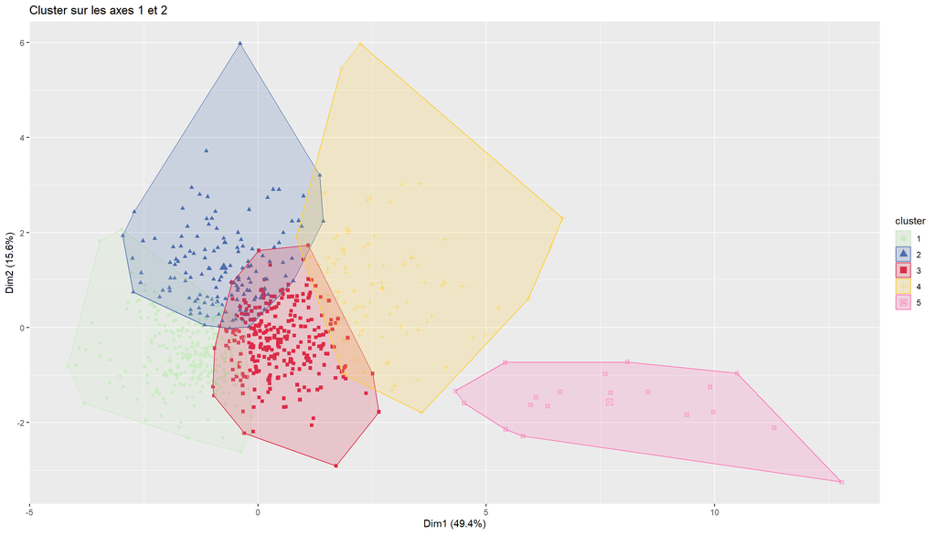

```r
fviz_cluster(res.hcpc,
             geom = "point",
             show.clust.cent = TRUE, # Show cluster centers
             palette = colCAH,         # Color palette ggpubr
             ggtheme = theme_grey(),
             main = "Cluster sur les axes 1 et 2",
             axes = c(1,2)
)
```

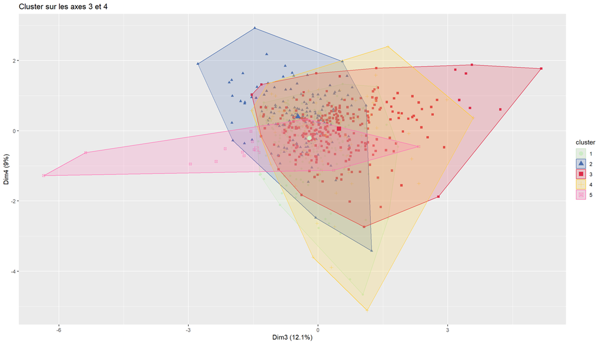

```r
fviz_cluster(res.hcpc,
             geom = "point",
             show.clust.cent = TRUE, # Show cluster centers
             palette = colCAH,         # Color palette ggpubr
             ggtheme = theme_grey(),
             main = "Cluster sur les axes 3 et 4",
             axes = c(3,4)
)
```

Choix du nombre de classe = 5

### 3.4.1 Descriptions des classes

#### 3.4.1.1 Positions moyennes sur les axes

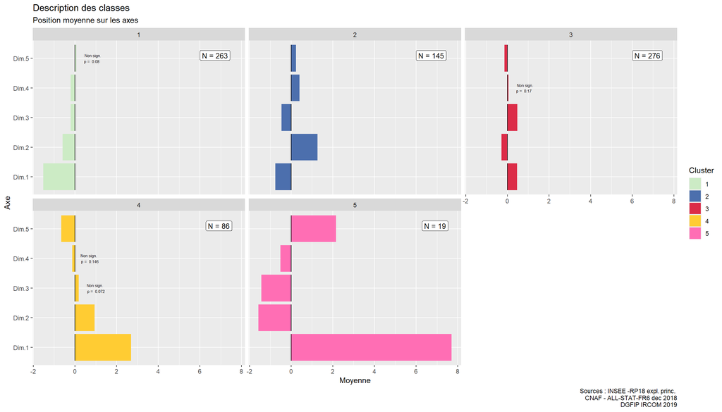

```r
## Individus par classes

Nclust <- res.hcpc$data.clust %>%
  group_by(clust)%>%
  summarise(N = n())%>%
  rename(Cluster = clust)

# classe selon la position moyenne sur les axes
ProfileAxe <- res.hcpc$desc.axes$quanti %>%
  imap_dfr(., ~as_tibble(., rownames = "Variable"),.id = "Cluster") %>%
  mutate(Axe = parse_number(Variable)*10 )



ggplot(ProfileAxe) +
  geom_bar(aes(x = Variable, y = `Mean in category`, fill = Cluster), stat = "identity") +
  scale_fill_manual(values = colCAH) +
  geom_errorbar(aes(x = Variable,
                    ymin = `Overall mean`, ymax = `Overall mean`),
                color = "black",
                linewidth = 0.5) +
  facet_wrap(~ Cluster) +
  geom_text(data = ProfileAxe %>% filter(p.value>0.05),
            mapping = aes(label = paste("Non sign.\np = ", round(p.value, digits = 3)),
                          x = Variable,
                          y = `Mean in category`),
            vjust = 0.5,
            hjust= -0.5,
            position = position_dodge(width = 0.8),
            size = 2) +
  geom_label(data = Nclust,
             mapping = aes(label = paste0("N = ", N)),
             size = 3.5,
             x = Inf, y = Inf ,
             hjust = 1.5,
             vjust = 2) +
  labs(title = "Description des classes",
       subtitle = "Position moyenne sur les axes",
       x = "Axe",
       y = "Moyenne",
       caption = "Sources : INSEE -RP18 expl. princ. \n CNAF - ALL-STAT-FR6 dec 2018\n DGFIP IRCOM 2019") +
  theme_grey() +
  coord_flip()
```

- AXE 1 : Cumul des marqueurs de précarité témoignant de l’éloignement à l’emploi (aides sociales, chômage) et des difficultés économiques qui en résultent (pauvreté des foyers fiscaux)
- AXE 2 : porté par la structure et les formes de l’emploi en marge du CDI (Intérim et emplois peu qualifiés en contrats courts)
- AXE 3 : structuré par la variable de nombre de bénéficiaires de l’AAH pour 1000 habitants
- AXE 4 : différencie deux formes d’emploi, l’intérim VS les emplois peu qualifiés en CDD
- AXE 5 : oppose les chômeurs de courte durée et les foyers retraités pauvres

#### 3.4.1.2 Valeurs moyennes par classe

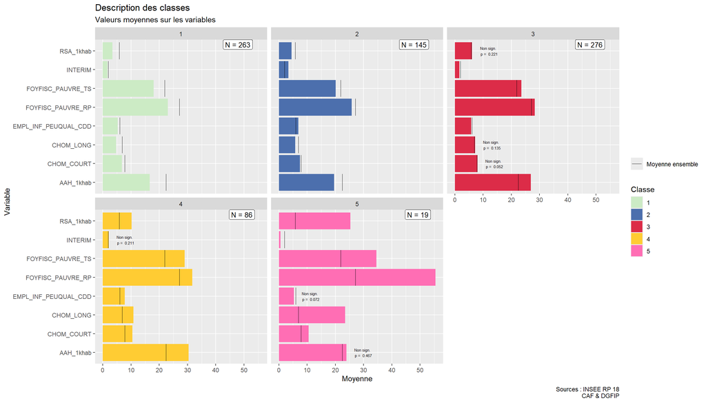

```r
# classe selon les valeurs moyennes par variables

ProfileVar <- res.hcpc$desc.var$quanti %>%
  imap_dfr(., ~as_tibble(., rownames = "Variable"),.id = "Cluster")

# Transformation de la variable RSA pour 1000 hab en pct (pour l'échelle)


ProfileVar <- ProfileVar %>%
  mutate(`Mean in category` = case_when(Variable == "RSA_1khab" ~ `Mean in category`/10,
                                        T ~ `Mean in category`),
         `Overall mean` = case_when(Variable == "RSA_1khab" ~ `Overall mean`/10,
                                        T ~ `Overall mean`))

# graphique
ggplot(ProfileVar) +
  geom_bar(aes(x = Variable, y = `Mean in category`, fill = Cluster), stat = "identity") +
  scale_fill_manual(values = colCAH) +
  geom_errorbar(aes(x = Variable,
                    ymin = `Overall mean`,
                    ymax = `Overall mean`,
                    color = "moy"),
                linewidth = 0.25) +
  scale_color_manual(values = c(moy = "black"),
                     labels = c(moy = "Moyenne ensemble")) +
  facet_wrap(~ Cluster) +
  geom_text(data = ProfileVar %>% filter(p.value>0.05),
            mapping = aes(label = paste("Non sign.\np = ", round(p.value, digits = 3)),
                          x = Variable,
                          y = `Mean in category`),
            vjust = 0.5,
            hjust= -0.5,
            position = position_dodge(width = 0.8),
            size = 2) +
  geom_label(data = Nclust,
             mapping = aes(label = paste0("N = ", N)),
             size = 3.5,
             x = Inf, y = Inf ,
             hjust = 1.5,
             vjust = 1) +
  labs(title = "Description des classes",
       subtitle = "Valeurs moyennes sur les variables",
       x = "Variable",
       y = "Moyenne",
       fill = "Classe",
       colour = "",
       caption = "Sources : INSEE RP 18\nCAF & DGFIP") +
  theme_grey() +
  coord_flip() +
   scale_y_continuous(breaks = scales::pretty_breaks(n = 8))
```

(Nb : RSA en pct pour cette représentation et non pas pour 1000 habitants )

- Classe 1 : 263 AU. Une précarité moins marquée dans les 3 dimensions. c’est la sous-représentation qui qualifie cette classe, mais ne signifie pas que la précarité est absente (presque un foyer fiscal sur cinq est “pauvre” monétairement).
- Classe 2 : 145 AU. Précarité assez forte dans les formes d’emploi. Moins de chômage, moins d’éloignement à l’emploi mais les emplois sont davantage “précaires” (interim, emplois d’exécution peu qualifiés en contrat court).
- Classe 3 : 276 AU. Une précarité assez forte, configurée par la pauvreté monétaire et les aides sociales (notamment l’AAH). Cumul des formes d’éloignement à l’emploi (axes 1 et 3). Davantage de chômage que les classes 1 et 2.
- Classe 4 : 86 AU. Précarité forte sur les trois dimensions
- Classe 5 : 19 AU. précarité très forte configurée par l’éloignement à l’emploi et les faibles revenus/la pauvreté

#### 3.4.1.3 Parangons et Individus spécifiques selon les classes

- *parangons* ($para) = individus représentatifs (milieu de classe) ;
- *individus spécifiques* ($dist) = individus d’une classe étant les plus éloignés des autres classes

```r
# paragons ($para) & individus spécifiques ($dist) par classe

res.hcpc$desc.ind
```

```
## $para
## Cluster: 1
##         Saint-Brieuc_22            Gérardmer_88    Tournon-sur-Rhône_07
##               0.3826039               0.4168446               0.4328134
##   Brive-la-Gaillarde_19          Albertville_73               Vittel_88
##               0.5727606               0.5910166               0.6110007
## Châlons-en-Champagne_51      Bourg-en-Bresse_01           Malestroit_56
##               0.6120428               0.6314095               0.6387715
##             Chaumont_52
##               0.6420645
## ------------------------------------------------------------
## Cluster: 2
##                             Sélestat_67                              Brioude_43
##                               0.4085188                               0.6673671
##                                Flers_61                              Thouars_79
##                               0.7046587                               0.7261813
##                            La Flèche_72                      Gournay-en-Bray_76
##                               0.7445190                               0.7701004
##                              Sézanne_51                 Romorantin-Lanthenay_41
##                               0.7745599                               0.7931924
## Feuquières-en-Vimeu - Fressenneville_80                                   Eu_76
##                               0.7934659                               0.7939048
## ------------------------------------------------------------
## Cluster: 3
##         Castelnaudary_11   Argenton-sur-Creuse_36 Cosne-Cours-sur-Loire_58
##                0.4176847                0.4718774                0.5599166
##               Pamiers_09              Bergerac_24            Douarnenez_29
##                0.5913797                0.6323016                0.6808631
##             Commentry_03   Châteauneuf-du-Faou_29             Rochefort_17
##                0.7141901                0.7155445                0.7204540
##             Montauban_82
##                0.7341611
## ------------------------------------------------------------
## Cluster: 4
##        Port-la-Nouvelle_11                 Péronne_80
##                  0.3069556                  0.4454373
##                Morhange_57                  Hesdin_62
##                  0.7846922                  0.8817358
##                Tonneins_47 Saint-Seurin-sur-l'Isle_33
##                  0.9703125                  1.0239951
```

[output cut: 54 more lines]

```
##                 5.267548                 5.093771                 4.853698
##     Avesnes-sur-Helpe_59
##                 4.749530
## ------------------------------------------------------------
## Cluster: 5
##             Maripasoula_973 Saint-Laurent-du-Maroni_973
##                   12.861417                   11.698532
##             Saint-Louis_974            Saint-Benoît_974
##                    8.853388                    8.736875
##            Saint-Joseph_974             Saint-André_974
##                    8.531347                    8.379440
##            Saint-Pierre_972              Bouillante_971
##                    6.649867                    6.625523
##              Le Lorrain_972            Sainte-Marie_972
##                    6.521766                    6.131682
```

#### 3.4.1.4 Cartographie des résultats

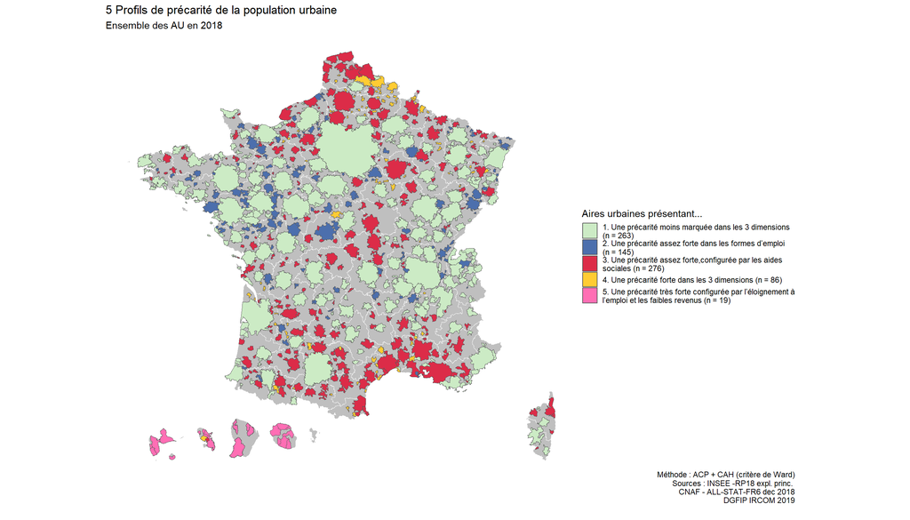

```r
## Cartographie

### Cartographie statiques


## Récupérer la typo
AU_carto <- AU_typo %>%
  bind_cols(., CAH = res.hcpc$data.clust$clust)


## ajout des géometries AU
AU_carto <- AU_carto %>%
  left_join(AUsf) %>% st_sf


# labelClass


CAHlabel <- data.frame(CAH = sort(unique(AU_carto$CAH)) ,
                       CAHlabs = c("1. Une précarité moins marquée dans les 3 dimensions",
                                   "2. Une précarité assez forte dans les formes d’emploi",
                                   "3. Une précarité assez forte,configurée par les aides sociales",
                                   "4. Une précarité forte dans les 3 dimensions",
                                   "5. Une précarité très forte configurée par l’éloignement à l’emploi et les faibles revenus"))

# couleur

colCAH <- setNames(c("#CCEBC5", "#4C6FAD",   "#DC2C48", "#FFCC33",  "hotpink1" ),
                   c(1,2,3,4,5) )


# ajout des comptages et labels
AU_carto <-AU_carto %>%
  left_join(CAHlabel, by ="CAH") %>%
  add_count(CAHlabs) %>%
  mutate(CAHlabel_n = paste0(CAHlabs, " (n = ", n, ")"))
## cartographie

g3 <-ggplot() +
  geom_sf(data =depsf, fill = "#bfbfbf", color = "white", size = 0.5) +
  geom_sf(data = AU_carto,
          mapping = aes(fill = CAH ), size = 0.25) +
  scale_fill_manual(values = colCAH,
                    labels = str_wrap(sort(unique(AU_carto$CAHlabel_n)),60),
                    breaks = 1:length(unique(AU_carto$CAHlabel_n))) +
  theme_void() +
  labs(title = "5 Profils de précarité de la population urbaine",
       subtitle = "Ensemble des AU en 2018",
       fill = "Aires urbaines présentant...",
       caption = "Méthode : ACP + CAH (critère de Ward)\nSources : INSEE -RP18 expl. princ. \n CNAF - ALL-STAT-FR6 dec 2018\n DGFIP IRCOM 2019")+
  theme(plot.caption.position = "plot",
        legend.margin = unit(c(0, 0, 0,0), "points"),
        plot.caption =element_text(vjust=10),
        plot.margin = unit(c(0, 10, 0,0), "points"),
        axis.ticks.length = unit(0, "points"))



# affichage de la carte
g3
```

```r
# version sans titre
g3 <- g3 + labs(title = "",
                subtitle = "")

# ggsave(plot = g3,
#        path =  "../Output/",
#        filename = "carto_cahpreca_2018_5classes.png",
#        width = 210,
#        height = 148,
#        dpi = 300,
#        device = "png",
#        units = "mm",
#        bg = "white")
```

# 4 Tableau des résultats

Tableau récapitulatif de la typologie.

```r
dfrecap <- AU_carto %>%
  st_drop_geometry() %>%
  relocate(CAHlabs, .after = DEP) %>%
   mutate(across(where(is.numeric), ~round(., 2)))  %>%
 select(-c("n","CAHlabel_n"))

# export
# write.csv2(dfrecap, "../Output/TypoPreca_AU_casd.csv", row.names = F, fileEncoding = "UTF-8")

sticky_style <- list(backgroundColor = "#f7f7f7")

reactable(dfrecap, filterable = TRUE, minRows = 10,  striped = TRUE,
            columns = list(
    AU2010 = colDef(
      sticky = "left",
      style = sticky_style,
      headerStyle = sticky_style
    ),
    LIBAU2010 = colDef(
      sticky = "left",
      style = sticky_style,
      headerStyle = sticky_style
    ),
    DEP = colDef(
      sticky = "left",
      style = sticky_style,
      headerStyle = sticky_style
    ),
    CAHlabs = colDef(
      sticky = "left",
      style = sticky_style,
      headerStyle = sticky_style
    )
  ),
  resizable = TRUE,
  wrap = FALSE,
  bordered = TRUE)
```

| AU2010 | LIBAU2010 | DEP | CAHlabs | RSA_1khab | AAH_1khab | FOYFISC_PAUVRE_RP | FOYFISC_PAUVRE_TS | INTERIM | EMPL_INF_PEUQUAL_CDD | CHOM_LONG | CHOM_COURT | CAH |
| --- | --- | --- | --- | --- | --- | --- | --- | --- | --- | --- | --- | --- |
| 001 | Paris | 75 | 1. Une précarité moins marquée dans les 3 dimensions | 53.32 | 12.69 | 20.18 | 16.71 | 1.11 | 2.85 | 5.37 | 6.76 | 1 |
| 002 | Lyon | 69 | 1. Une précarité moins marquée dans les 3 dimensions | 48.08 | 14.44 | 20.94 | 16.87 | 1.95 | 3.85 | 4.47 | 7.18 | 1 |
| 003 | Marseille - Aix-en-Provence | 13 | 3. Une précarité assez forte,configurée par les aides sociales | 88.52 | 17.56 | 27.48 | 21.38 | 1.26 | 3.54 | 6.42 | 7.93 | 3 |
| 004 | Toulouse | 31 | 1. Une précarité moins marquée dans les 3 dimensions | 50.47 | 17.74 | 22.66 | 18.87 | 1.76 | 3.37 | 4.88 | 7.27 | 1 |
| 005 | Lille (partie française) | 59 | 3. Une précarité assez forte,configurée par les aides sociales | 91.23 | 19.78 | 24.83 | 21.83 | 1.48 | 4.25 | 7.61 | 8.04 | 3 |
| 006 | Bordeaux | 33 | 1. Une précarité moins marquée dans les 3 dimensions | 48.84 | 16.31 | 21.25 | 18.77 | 1.69 | 3.92 | 4.87 | 7.4 | 1 |
| 007 | Nice | 06 | 1. Une précarité moins marquée dans les 3 dimensions | 44.1 | 20.26 | 26.92 | 18.52 | 1.07 | 3.54 | 5.37 | 7.91 | 1 |
| 008 | Nantes | 44 | 1. Une précarité moins marquée dans les 3 dimensions | 42.41 | 14.16 | 19.85 | 17.13 | 1.9 | 4 | 4.19 | 6.76 | 1 |
| 009 | Strasbourg (partie française) | 67 | 1. Une précarité moins marquée dans les 3 dimensions | 56.53 | 13.45 | 20.73 | 18.28 | 1.85 | 4.1 | 5.25 | 7.08 | 1 |
| 010 | Grenoble | 38 | 1. Une précarité moins marquée dans les 3 dimensions | 41.27 | 14.79 | 20.46 | 16.88 | 1.51 | 3.97 | 4.45 | 6.7 | 1 |

[output cut: 779 more lines]